# Comparing two proportions (binary response)

### Classical analysis of variance model:

```r
require(ez)
#summary(aov_model <- aov(y ~ cond + Error(sub/cond), data=ot))

ez_model <- ezANOVA(data=ot,
                    dv=y,
                    wid=sub,
                    within = cond)
print(ez_model)
```

```
## $ANOVA
##   Effect DFn DFd        F            p p<.05       ges
## 2   cond   4  76 263.8887 9.838218e-44     * 0.6729657
##
## $`Mauchly's Test for Sphericity`
##   Effect         W         p p<.05
## 2   cond 0.5387183 0.2936683
##
## $`Sphericity Corrections`
##   Effect       GGe        p[GG] p[GG]<.05       HFe        p[HF] p[HF]<.05
## 2   cond 0.8030204 1.405266e-35         * 0.9855897 3.883502e-43         *
```

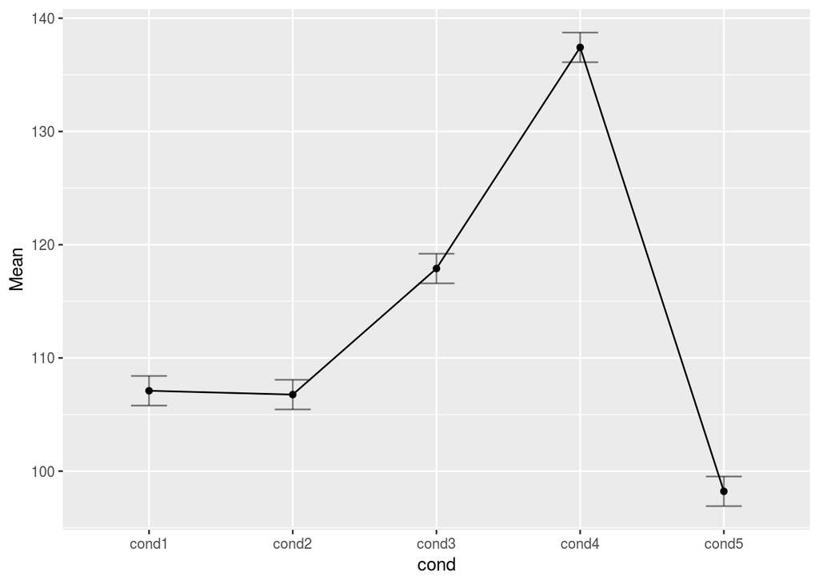

```r
ezPlot(data=ot,
       dv=y,
       wid=sub,
       within = cond,
       x = cond)
```

```r
require(lme4)
summary(lmer_model <- lmer(y ~ cond + (1 | sub), data=ot))
```

```
## Linear mixed model fit by REML ['lmerMod']
## Formula: y ~ cond + (1 | sub)
##    Data: ot
##
## REML criterion at convergence: 614.8
##
## Scaled residuals:
##      Min       1Q   Median       3Q      Max
## -2.50719 -0.47989 -0.02761  0.57325  2.41934
##
## Random effects:
##  Groups   Name        Variance Std.Dev.
##  sub      (Intercept) 75.98    8.717
##  Residual             17.27    4.156
## Number of obs: 100, groups:  sub, 20
##
## Fixed effects:
##             Estimate Std. Error t value
## (Intercept) 107.0996     2.1593  49.599
## condcond2    -0.3382     1.3142  -0.257
## condcond3    10.7948     1.3142   8.214
## condcond4    30.3236     1.3142  23.075
## condcond5    -8.8795     1.3142  -6.757
##
## Correlation of Fixed Effects:
##           (Intr) cndcn2 cndcn3 cndcn4
## condcond2 -0.304
## condcond3 -0.304  0.500
## condcond4 -0.304  0.500  0.500
## condcond5 -0.304  0.500  0.500  0.500
```

```r
anova(lmer_model)
```

```
## Analysis of Variance Table
##      Df Sum Sq Mean Sq F value
## cond  4  18230  4557.4  263.89
```

```r
require(car)
Anova(lmer_model)
```

```
## Analysis of Deviance Table (Type II Wald chisquare tests)
##
## Response: y
##       Chisq Df Pr(>Chisq)
## cond 1055.6  4  < 2.2e-16 ***
## ---
## Signif. codes:  0 '***' 0.001 '**' 0.01 '*' 0.05 '.' 0.1 ' ' 1
```

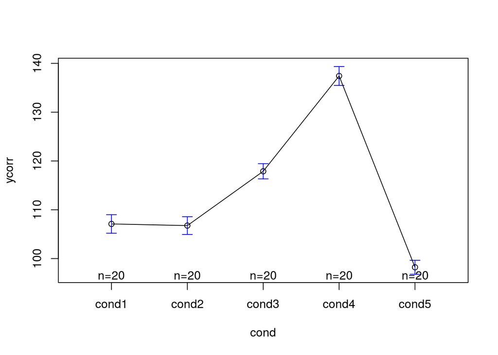

```r
# plotmeans(y ~ cond, data=ot, gap=0.1) #
plotmeans(ycorr ~ cond, data=ot, gap=0.1)
```

# Factorial ANOVAs

```r
rm(list=ls())
require(ez)
```

Generation of a dataset S<A3*B2>

```r
subject = factor(paste('sub', 1:30, sep=''))
A = gl(3 ,10, 30, labels=c('a1','a2','a3'))
B = gl(2, 5, 30, labels=c('a2', 'b2'))
x = rnorm(30, mean=10) + 1 * (A=='a1' & B=='b2')
dat = data.frame(subject, A, B, x)
```

```r
rm(subject, A, B, x)
attach(dat)
```

Classical R approach

```r
table(A, B)
```

```
##     B
## A    a2 b2
##   a1  5  5
##   a2  5  5
##   a3  5  5
```

```r
tapply(x, list(A, B), mean)
```

```
##           a2        b2
## a1 10.216758 10.634384
## a2 10.734730  9.904646
## a3  9.840301  9.644966
```

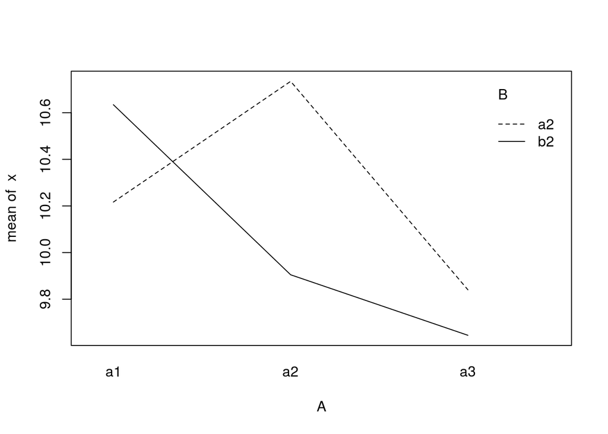

```r
interaction.plot(A,B,x)
```

```r
summary(aov(x ~ A * B, data=dat))
```

```
##             Df Sum Sq Mean Sq F value Pr(>F)
## A            2  2.702  1.3510   1.785  0.189
## B            1  0.308  0.3078   0.407  0.530
## A:B          2  1.946  0.9731   1.286  0.295
## Residuals   24 18.161  0.7567
```

Using ez

```
## Coefficient covariances computed by hccm()
```

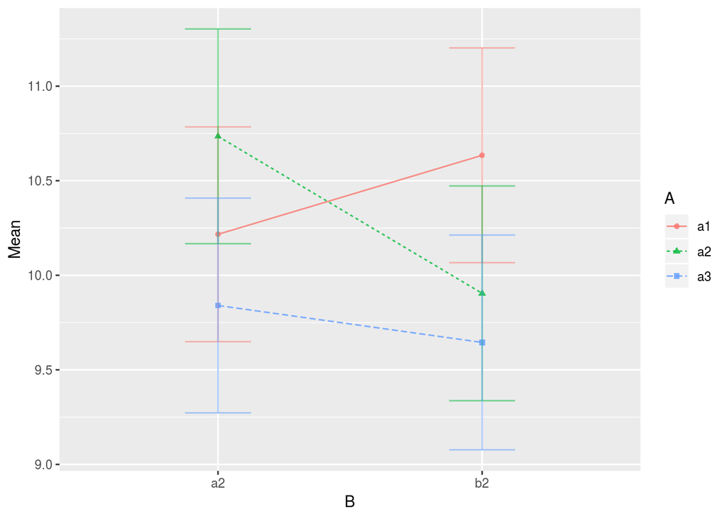

```r
ezPlot(data=dat,  dv=.(x), wid=.(subject), between=.(A,B),
       x=.(B), split=.(A))
```

```r
ezANOVA(data=dat, dv=x, wid=subject, between=c('A','B'))
```

```
## Coefficient covariances computed by hccm()
```

```
## $ANOVA
##   Effect DFn DFd         F         p p<.05        ges
## 1      A   2  24 1.7853395 0.1893064       0.12951001
## 2      B   1  24 0.4068109 0.5296315       0.01666793
## 3    A:B   2  24 1.2859191 0.2947648       0.09678812
##
## $`Levene's Test for Homogeneity of Variance`
##   DFn DFd       SSn      SSd         F         p p<.05
## 1   5  24 0.4239339 11.42751 0.1780687 0.9682028
```

```r
detach(dat)
```

Same dataset but with A & B within subject

```r
subject = gl(5, 1, 30, labels=paste('sub', 1:5, sep=''))
dat$subject = subject
table(dat$subject, dat$A, dat$B)
```

```
## , ,  = a2
##
##
##        a1 a2 a3
##   sub1  1  1  1
##   sub2  1  1  1
##   sub3  1  1  1
##   sub4  1  1  1
##   sub5  1  1  1
##
## , ,  = b2
##
##
##        a1 a2 a3
##   sub1  1  1  1
##   sub2  1  1  1
##   sub3  1  1  1
##   sub4  1  1  1
##   sub5  1  1  1
```

```r
attach(dat)
```

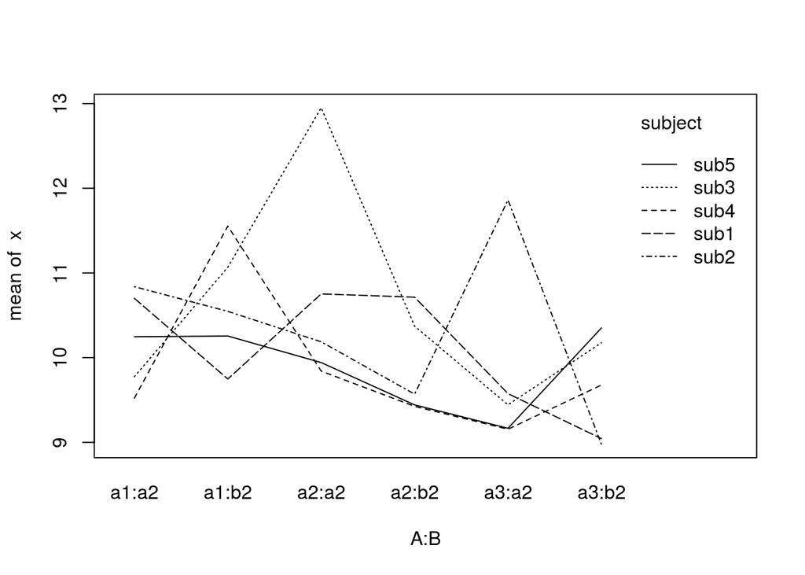

```r
interaction.plot(A:B, subject, x)
```

```r
summary(aov(x ~ A*B + Error(subject/(A*B))))
```

```
##
## Error: subject
##           Df Sum Sq Mean Sq F value Pr(>F)
## Residuals  4  2.471  0.6177
##
## Error: subject:A
##           Df Sum Sq Mean Sq F value Pr(>F)
## A          2  2.702  1.3510   1.995  0.198
## Residuals  8  5.418  0.6773
##
## Error: subject:B
##           Df Sum Sq Mean Sq F value Pr(>F)
## B          1  0.308  0.3078   0.366  0.578
## Residuals  4  3.369  0.8422
##
## Error: subject:A:B
##           Df Sum Sq Mean Sq F value Pr(>F)
## A:B        2  1.946  0.9731   1.128   0.37
## Residuals  8  6.903  0.8629
```

```r
#summary(aov(x ~ A + Error(subject/A), data=dat, subset= (B==1)))
#summary(aov(x ~ A + Error(subject/A), data=dat, subset= (B==2)))

for (a in levels(A))
  {
  print(paste("Effect of B for A =",a))
  print(summary(aov(x ~ B + Error(subject/(B), data=dat, subset=(A==a)))))
}
```

```
## [1] "Effect of B for A = a1"
##
## Error: subject
##           Df Sum Sq Mean Sq F value Pr(>F)
## Residuals  4  2.471  0.6177
##
## Error: subject:B
##           Df Sum Sq Mean Sq F value Pr(>F)
## B          1  0.308  0.3078   0.366  0.578
## Residuals  4  3.369  0.8422
##
## Error: Within
##           Df Sum Sq Mean Sq F value Pr(>F)
## Residuals 20  16.97  0.8485
## [1] "Effect of B for A = a2"
##
## Error: subject
##           Df Sum Sq Mean Sq F value Pr(>F)
## Residuals  4  2.471  0.6177
##
## Error: subject:B
##           Df Sum Sq Mean Sq F value Pr(>F)
## B          1  0.308  0.3078   0.366  0.578
## Residuals  4  3.369  0.8422
##
## Error: Within
##           Df Sum Sq Mean Sq F value Pr(>F)
## Residuals 20  16.97  0.8485
## [1] "Effect of B for A = a3"
##
## Error: subject
##           Df Sum Sq Mean Sq F value Pr(>F)
## Residuals  4  2.471  0.6177
##
## Error: subject:B
##           Df Sum Sq Mean Sq F value Pr(>F)
## B          1  0.308  0.3078   0.366  0.578
## Residuals  4  3.369  0.8422
##
## Error: Within
##           Df Sum Sq Mean Sq F value Pr(>F)
## Residuals 20  16.97  0.8485
```

```r
detach(dat)
```

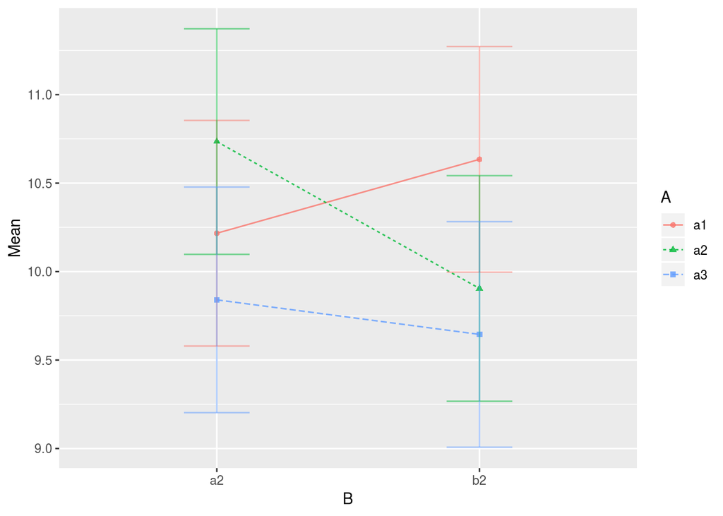

```r
ezPlot(data=dat,  dv=.(x), wid=.(subject), between=.(A), within=.(B),
       x=.(B), split=.(A))
```

```r
ezANOVA(data=dat,
        dv=x,
        wid=subject,
        within=.(A, B))
```

```
## $ANOVA
##   Effect DFn DFd         F         p p<.05        ges
## 2      A   2   8 1.9947766 0.1982202       0.12951001
## 3      B   1   4 0.3655111 0.5780792       0.01666793
## 4    A:B   2   8 1.1276448 0.3703124       0.09678812
##
## $`Mauchly's Test for Sphericity`
##   Effect         W         p p<.05
## 2      A 0.2915359 0.1574120
## 4    A:B 0.8551403 0.7907807
##
## $`Sphericity Corrections`
##   Effect       GGe     p[GG] p[GG]<.05       HFe     p[HF] p[HF]<.05
## 2      A 0.5853210 0.2254362           0.6809337 0.2192077
## 4    A:B 0.8734695 0.3670485           1.4945655 0.3703124
```

Split-plot ANOVA (A within, B between)

```r
subject = gl(10, 1, 30, labels=paste('sub', 1:10, sep=''))
dat$subject = subject
table(dat$subject, dat$A, dat$B)
```

```
## , ,  = a2
##
##
##         a1 a2 a3
##   sub1   1  1  1
##   sub2   1  1  1
##   sub3   1  1  1
##   sub4   1  1  1
##   sub5   1  1  1
##   sub6   0  0  0
##   sub7   0  0  0
##   sub8   0  0  0
##   sub9   0  0  0
##   sub10  0  0  0
##
## , ,  = b2
##
##
##         a1 a2 a3
##   sub1   0  0  0
##   sub2   0  0  0
##   sub3   0  0  0
##   sub4   0  0  0
##   sub5   0  0  0
##   sub6   1  1  1
##   sub7   1  1  1
##   sub8   1  1  1
##   sub9   1  1  1
##   sub10  1  1  1
```

```r
table(dat$subject, dat$B:dat$A)
```

```
##
##         a2:a1 a2:a2 a2:a3 b2:a1 b2:a2 b2:a3
##   sub1      1     1     1     0     0     0
##   sub2      1     1     1     0     0     0
##   sub3      1     1     1     0     0     0
##   sub4      1     1     1     0     0     0
##   sub5      1     1     1     0     0     0
##   sub6      0     0     0     1     1     1
##   sub7      0     0     0     1     1     1
##   sub8      0     0     0     1     1     1
##   sub9      0     0     0     1     1     1
##   sub10     0     0     0     1     1     1
```

```r
summary(aov(x ~ A*B + Error(subject/A), data=dat))
```

```
##
## Error: subject
##           Df Sum Sq Mean Sq F value Pr(>F)
## B          1  0.308  0.3078   0.422  0.534
## Residuals  8  5.840  0.7300
##
## Error: subject:A
##           Df Sum Sq Mean Sq F value Pr(>F)
## A          2  2.702  1.3510   1.754  0.205
## A:B        2  1.946  0.9731   1.264  0.309
## Residuals 16 12.322  0.7701
```

```r
ezANOVA(data=dat, dv=x, wid=subject, within=.(A), between=.(B))
```

```
## $ANOVA
##   Effect DFn DFd         F         p p<.05        ges
## 2      B   1   8 0.4217255 0.5342740       0.01666793
## 3      A   2  16 1.7543182 0.2047126       0.12951001
## 4    B:A   2  16 1.2635756 0.3093789       0.09678812
##
## $`Mauchly's Test for Sphericity`
##   Effect         W         p p<.05
## 3      A 0.6649966 0.2398104
## 4    B:A 0.6649966 0.2398104
##
## $`Sphericity Corrections`
##   Effect       GGe     p[GG] p[GG]<.05       HFe     p[HF] p[HF]<.05
## 3      A 0.7490618 0.2150427           0.8830614 0.2097144
## 4    B:A 0.7490618 0.3051663           0.8830614 0.3080005
```

# Correlated regressors in multiple regression

It is often asserted that one two (or more) independent variables are correlated, this creates a problem in multiple regression. What problem? And when is it serious?

In multiple regression, the coefficients estimated for each regressor represents the influence of the associated variable *when the others are kept constant*. It is the “unique” contribution of this variable.

```r
require(mvtnorm)
```

```
##
##  Pearson's product-moment correlation
##
## data:  x1 and x2
## t = 0.29462, df = 98, p-value = 0.7689
## alternative hypothesis: true correlation is not equal to 0
## 95 percent confidence interval:
##  -0.1676497  0.2248523
## sample estimates:
##        cor
## 0.02974801
##
## [1] "VIF:"
##       x1       x2
## 1.000886 1.000886
```

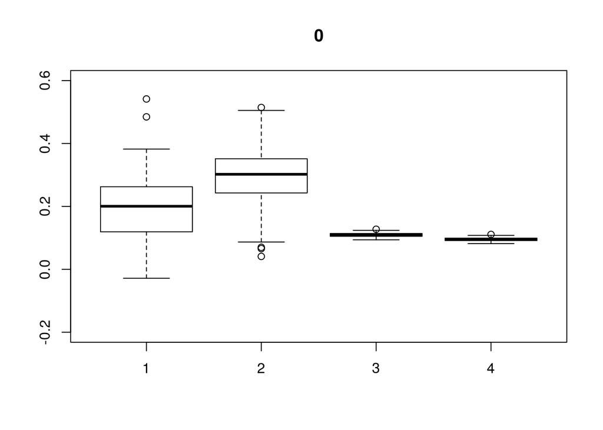

```
##                [,1]       [,2]       [,3]       [,4]
## Min.    -0.02848129 0.04097703 0.09375804 0.08163134
## 1st Qu.  0.11927397 0.24599690 0.10502265 0.09143898
## Median   0.20046899 0.30205428 0.10887665 0.09479451
## Mean     0.19321677 0.29747621 0.10910268 0.09499130
## 3rd Qu.  0.26169694 0.35104835 0.11383441 0.09911103
## Max.     0.54153665 0.51444123 0.12732899 0.11086021
##
##  Pearson's product-moment correlation
##
## data:  x1 and x2
## t = 1.1942, df = 98, p-value = 0.2353
## alternative hypothesis: true correlation is not equal to 0
## 95 percent confidence interval:
##  -0.07850159  0.30891449
## sample estimates:
##       cor
## 0.1197632
##
## [1] "VIF:"
##       x1       x2
## 1.014552 1.014552
```

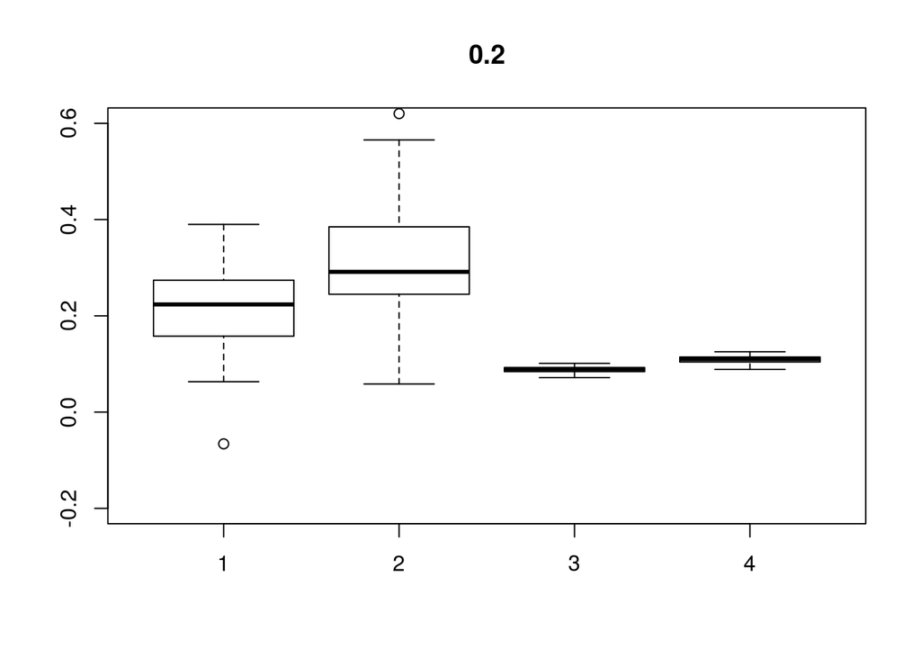

```
##               [,1]       [,2]       [,3]       [,4]
## Min.    -0.0659696 0.05837073 0.07168017 0.08869193
## 1st Qu.  0.1580601 0.24479933 0.08410197 0.10406179
## Median   0.2236808 0.29146045 0.08902285 0.11015053
## Mean     0.2120548 0.30711317 0.08854040 0.10955358
## 3rd Qu.  0.2737401 0.38199629 0.09243936 0.11437788
## Max.     0.3899685 0.62011927 0.10126540 0.12529859
##
##  Pearson's product-moment correlation
##
## data:  x1 and x2
## t = 2.9121, df = 98, p-value = 0.004446
## alternative hypothesis: true correlation is not equal to 0
## 95 percent confidence interval:
##  0.09082395 0.45348857
## sample estimates:
##       cor
## 0.2822076
##
## [1] "VIF:"
##       x1       x2
## 1.086533 1.086533
```

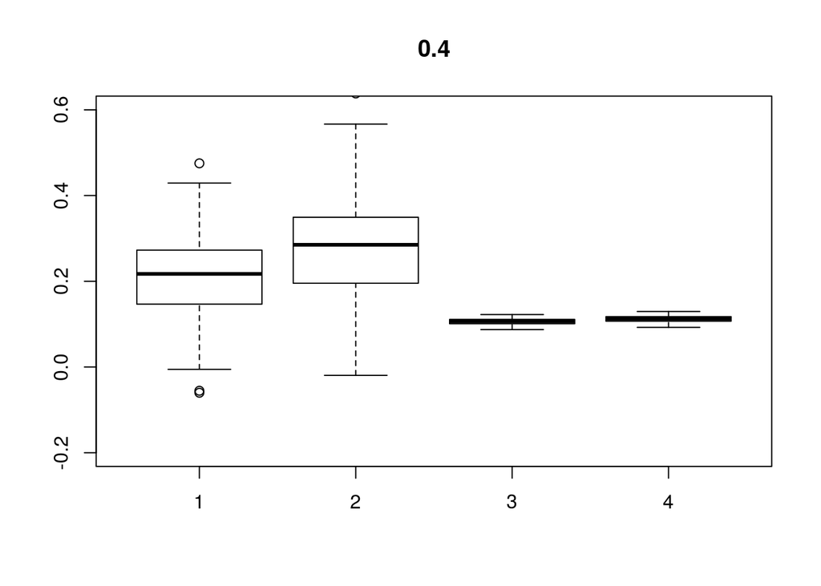

```
##                [,1]        [,2]       [,3]       [,4]
## Min.    -0.06004085 -0.01946689 0.08727899 0.09239743
## 1st Qu.  0.14749477  0.19634494 0.10110625 0.10703558
## Median   0.21730513  0.28518197 0.10632886 0.11256447
## Mean     0.21001849  0.28310143 0.10604756 0.11226668
## 3rd Qu.  0.27181427  0.34924964 0.11100285 0.11751256
## Max.     0.47517547  0.63811383 0.12229727 0.12946934
##
##  Pearson's product-moment correlation
##
## data:  x1 and x2
## t = 6.1347, df = 98, p-value = 1.807e-08
## alternative hypothesis: true correlation is not equal to 0
## 95 percent confidence interval:
##  0.3684550 0.6553634
## sample estimates:
##       cor
## 0.5267515
##
## [1] "VIF:"
##      x1      x2
## 1.38402 1.38402
```

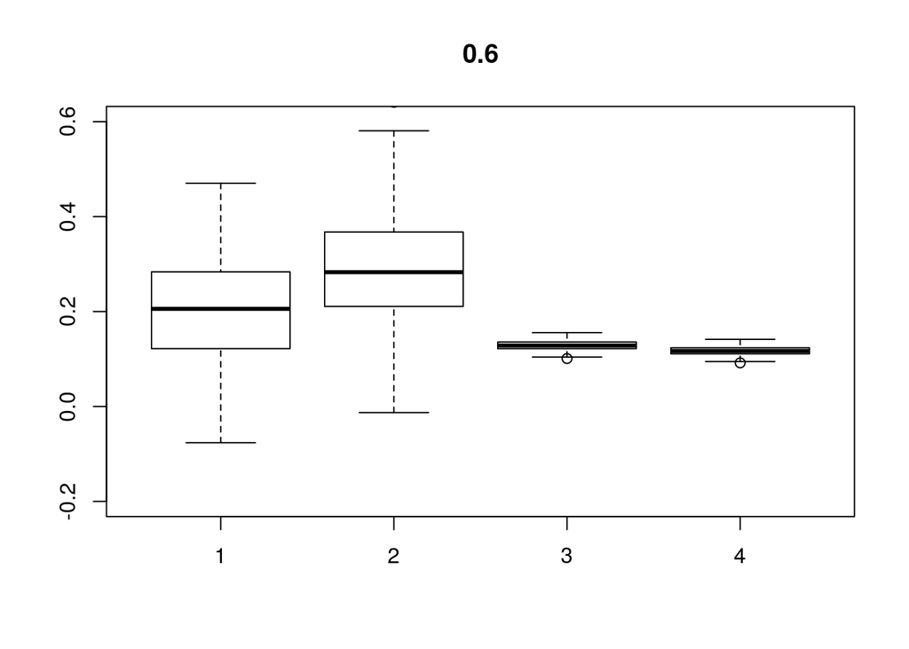

```
##                [,1]        [,2]      [,3]       [,4]
## Min.    -0.07639905 -0.01290163 0.1009632 0.09184004
## 1st Qu.  0.12236029  0.21067297 0.1218839 0.11087030
## Median   0.20568520  0.28291232 0.1283489 0.11675106
## Mean     0.19898915  0.28934190 0.1289292 0.11727896
## 3rd Qu.  0.28296488  0.36565311 0.1357641 0.12349623
## Max.     0.47010032  0.64072393 0.1555047 0.14145307
##
##  Pearson's product-moment correlation
##
## data:  x1 and x2
## t = 13.662, df = 98, p-value < 2.2e-16
## alternative hypothesis: true correlation is not equal to 0
## 95 percent confidence interval:
##  0.7293502 0.8681073
## sample estimates:
##       cor
## 0.8097636
##
## [1] "VIF:"
##       x1       x2
## 2.904587 2.904587
```

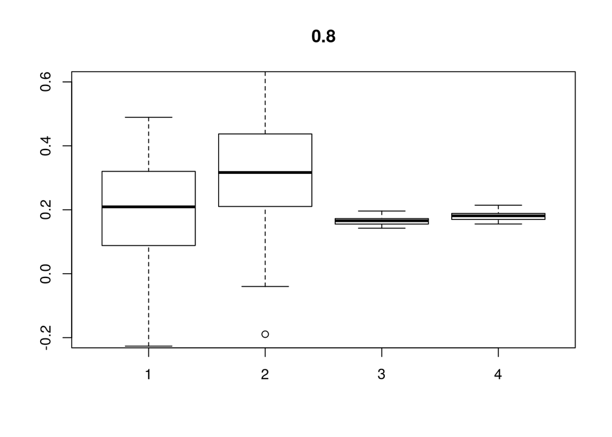

```
##                [,1]       [,2]      [,3]      [,4]
## Min.    -0.22660425 -0.1893621 0.1422677 0.1554952
## 1st Qu.  0.09167271  0.2103744 0.1551767 0.1696043
## Median   0.20906899  0.3165493 0.1656297 0.1810292
## Mean     0.20297596  0.3119089 0.1649150 0.1802481
## 3rd Qu.  0.31971208  0.4364224 0.1722255 0.1882383
## Max.     0.67118860  0.9297187 0.1960170 0.2142419
```

```r
require(car)

n <- 100
a1 <- 0.2
a2 <- 0.3
nsim <- 100

for (cor in c(0, .2, .4, .6, .8))
  {
  d <- rmvnorm(n, sigma=matrix(c(1, cor, cor, 1), nrow=2))
  x1 <- d[,1]
  x2 <- d[,2]
  print(cor.test(x1, x2))
  print("VIF:")
  print(vif(lm(rnorm(n)~x1 + x2)))

  stats <- matrix(NA, nrow=nsim, ncol=4)
  for (i in 1:nsim)
    {
    y <- a1 * x1 + a2 * x2 + rnorm(n)
    lmmod <-lm(y ~ x1 + x2)
    slm <- summary(lmmod)

    stats[i,] <- as.numeric(slm$coefficients[2:3, 1:2])
    }
  boxplot(stats, main=cor, ylim=c(-0.2,0.6))
  print(apply(stats, 2, summary))
}
```

## display of parameters of lm in a simle 2x2 anova

### model with interaction

```r
a=gl(2,1,4)
b=gl(2,2,4)
means=c(4,6,10,15)


par(las=1)

interaction.plot(a,b,means,ylim=c(0,17),legend=F,type='b',pch=16,bty="l")

eps=.9
text(1,4+eps,"a1b1")
text(2,6+eps,"a2b1")
text(1,10+eps,"a1b2")
text(2,15+eps,"a2b2")

lines(c(1,2),c(10,12),lty=3)

arrows(1,0,1,4, code=3,length=.1)
arrows(2,4,2,6, code=3, length=.1)
arrows(1,4,1,10, code=3, length=.1)
arrows(2,12,2,15, code=3, length=.1)


mod1 = lm(means~a*b)
model.matrix(mod1)
```

```
##   (Intercept) a2 b2 a2:b2
## 1           1  0  0     0
## 2           1  1  0     0
## 3           1  0  1     0
## 4           1  1  1     1
## attr(,"assign")
## [1] 0 1 2 3
## attr(,"contrasts")
## attr(,"contrasts")$a
## [1] "contr.treatment"
##
## attr(,"contrasts")$b
## [1] "contr.treatment"
```

```r
summary(mod1)
```

```
##
## Call:
## lm(formula = means ~ a * b)
##
## Residuals:
## ALL 4 residuals are 0: no residual degrees of freedom!
##
## Coefficients:
##             Estimate Std. Error t value Pr(>|t|)
## (Intercept)        4         NA      NA       NA
## a2                 2         NA      NA       NA
## b2                 6         NA      NA       NA
## a2:b2              3         NA      NA       NA
##
## Residual standard error: NaN on 0 degrees of freedom
## Multiple R-squared:      1,  Adjusted R-squared:    NaN
## F-statistic:   NaN on 3 and 0 DF,  p-value: NA
```

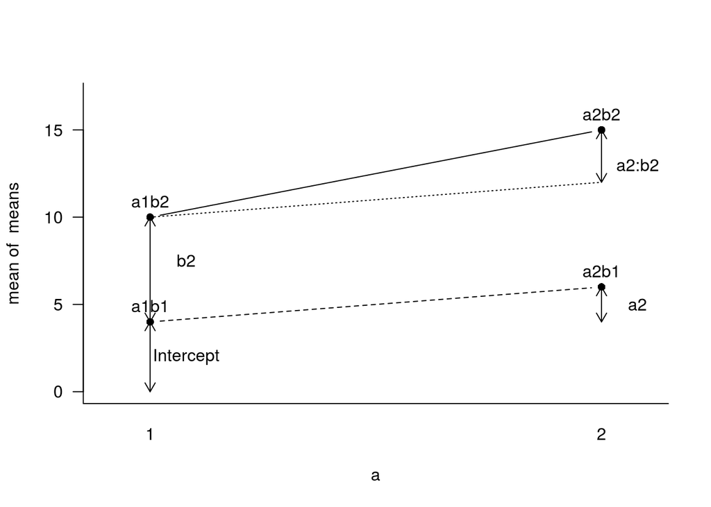

```r
text(1.08,2,"Intercept") # intercept
text(2.08,5,"a2") # a2
text(1.08,7.5,"b2") # b2
text(2.08,13,"a2:b2") # a2:b2
```

### Additive model

```r
tapply(means,list(a=a,b=b),mean)
```

```
##    b
## a   1  2
##   1 4 10
##   2 6 15
```

```r
diff(tapply(means,list(a),mean)) # main effect of a
```

```
##   2
## 3.5
```

```r
diff(tapply(means,list(b),mean)) # main effect of b
```

```
##   2
## 7.5
```

```r
summary(mod2<-lm(means~a+b))
```

```
##
## Call:
## lm(formula = means ~ a + b)
##
## Residuals:
##     1     2     3     4
##  0.75 -0.75 -0.75  0.75
##
## Coefficients:
##             Estimate Std. Error t value Pr(>|t|)
## (Intercept)    3.250      1.299   2.502    0.242
## a2             3.500      1.500   2.333    0.258
## b2             7.500      1.500   5.000    0.126
##
## Residual standard error: 1.5 on 1 degrees of freedom
## Multiple R-squared:  0.9682, Adjusted R-squared:  0.9046
## F-statistic: 15.22 on 2 and 1 DF,  p-value: 0.1783
```

```r
model.matrix(mod2)
```

```
##   (Intercept) a2 b2
## 1           1  0  0
## 2           1  1  0
## 3           1  0  1
## 4           1  1  1
## attr(,"assign")
## [1] 0 1 2
## attr(,"contrasts")
## attr(,"contrasts")$a
## [1] "contr.treatment"
##
## attr(,"contrasts")$b
## [1] "contr.treatment"
```

```r
model.tables(aov(means~a+b))
```

```
## Tables of effects
##
##  a
## a
##     1     2
## -1.75  1.75
##
##  b
## b
##     1     2
## -3.75  3.75
```

```r
model.tables(aov(means~a*b))
```

```
## Tables of effects
##
##  a
## a
##     1     2
## -1.75  1.75
##
##  b
## b
##     1     2
## -3.75  3.75
##
##  a:b
##    b
## a   1     2
##   1  0.75 -0.75
##   2 -0.75  0.75
```